[figure not shown]

**CFR El Tejado**  
Gral. Rodríguez  
Provincia de Buenos Aires

# Planificación anual 2025

## Salud y adolescencia

**Docente:** José Gustavo Juarez

**Curso:** 4°

**Horas semanales:** 2 hs (reloj)

## 1. Mapa Conceptual

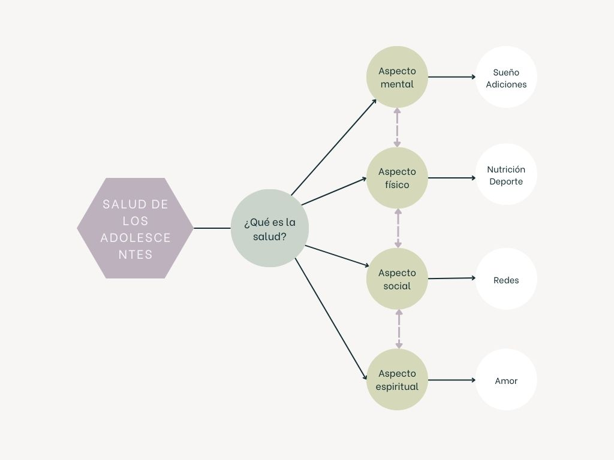

## 2. Fundamentación

La adolescencia es un periodo en el que se empiezan a pensar y tomar decisiones por cuenta propia. Al mismo tiempo aun hay una fuerte dependencia de los padres. Sumado a que el cuerpo también crece y la madurés se va alcanzando de a poco es un periodo en el que pueden crearse tensiones entre el adolescente y el mundo que le rodea.

Esta materia intenta orientar buenas desiciones y buenos hábitos desde lo físico, lo mental, lo social y lo espiritual. Pués todo está interelacionado y es crucial ayudar a que nazca de adentro respetando la libertad pero marcando también la responsabilidad y los límites que esta tiene.

Todo esto contribuye a la salud y a fomentar una juventud llena de buenas iniciativas e ideales. En donde el respeto a la dignidad de los demás y de sí mismo es un pilar importante.

## 3. Propósitos de enseñanza

Estos son:

- Fomentar la reflexión sobre la felicidad, el amor y la salud.
- Explicar aspectos de la salud mental, física y social desde un punto de vista científico (cosas comprobadas, no teorías) y asequibles a la edad
- Promover la buena relación con la propia familia, entre compañeros y las personas que lo rodean, como una parte importante de la felicidad (Investigación de Harvard)
- Fomentar acciones que ayuden a la aceptación de sí mismo y a poner el foco en el servicio a los demás
- Comprender que obsecionarse con la propia salud o apariencia exterior pueden constituir situaciones enfermizas (falta de salud)

## 4. Objetivos

Se espera que los alumnos logren:

- Relacionar la felicidad con la buenas relaciones con los semejantes y con el Creador
- Comprender la necesidad de fomentar buenos hábitos relacionados con la salud mental, corporal y social
- Comprender que el amor consiste en querer el bien del otro y no en usarlo para el propio placer
- Analizar casos aplicando diversos conocimientos sobre la salud
- Comprender que así como hay derecho a la salud también hay obligación de cuidarla en uno mismo y en los demás
- Relacionar aspectos históricos de la salud pública con comportamientos actuales

## 5. Contenidos

1. Vida. Etapas de la vida.
2. Pensando en mi futuro.
3. La felicidad, una aspiración de todo ser humano.
- **Estrategias, actividades y recursos**: Análisis de video sobre la investigación de Harvard sobre la felicidad.
4. Conceptualizaciones sobre la salud.Teorías para su abordaje.Historia natural de los procesos salud enfermedad. Medicinas tradicionales y populares.
- **Estrategias, actividades y recursos**: Análisis de un video que aporta una nueva definición de salud.
5. El derecho a la salud, salud y desarrollo social. Desarrollo histórico de la salud pública y comunitaria, sus objetivos y campos de acción.
- **Estrategias, actividades y recursos**: Análisis de un video sobre la epidemia de fiebre amarilla en Buenos Aires.
6. Rol del estado en la atención de la salud. Sistema Sanitario Argentino: conceptos, componentes, programas y proyectos para la atención de la salud provenientes de los efectores a nivel Nacional, Provincial y Municipal.
- **Estrategias, actividades y recursos**: Investigación de campo en el propio barrio sobre el estado y medios de salud pública que hay.
7. Desarrollo histórico de la Promoción y Educación para la Salud. Sus objetivos y campos de acción.
8. Concepto de prevención y niveles de prevención primario, secundario y terciario para la atención integral de la salud.
- **Estrategias, actividades y recursos**: Clasificación de casos reales. Investigación de campañas actuales o históricas.
9. Nutrición y salud en la adolescencia, malnutrición, desnutrición y obesidad. Trastornos de la conducta alimentaria: anorexia, bulimia.
- **Estrategias, actividades y recursos**: Análisis del caso Sofía.
10. Adolescencia y salud mental: Stress, depresión, tiempo libre, violencia, suicidio, factores de riesgo, la importancia de la familia, el grupo de pares y la escuela como espacios de contención.
- **Estrategias, actividades y recursos**: Análisis sobre la aceptación de sí mismo (El circo de las mariposas).
11. Sexualidad y adolescencia: la sexualidad en el contexto de la salud, sexualidad responsable, medidas de prevención ante las enfermedades de transmisión sexual y el SIDA. La pareja adolescente y el embarazo, importancia del diagnóstico precoz y sus cuidados.
- **Estrategias, actividades y recursos**: Análisis de video sobre el Sida (u otro similar). Análisis de caso.
12. Escuela, comunidad y salud: reconocimiento del barrio, identificación de recursos materiales y humanos que realizan acciones para el cuidado de la salud. Las redes sociales, concepto,conformación y fines.
- **Estrategias, actividades y recursos**: Promover acciones de servicio que pongan el foco en algo distinto a sí mismo
13. Alumnos y docentes como promotores de salud: proyectos educativos institucionales y comunitarios, conceptos y requisitos para su diseño e implementación, estrategias participativas para el abordaje de las distintas problemáticas (talleres, jornadas, radio, foros de opinión, obras de teatro, títeres, etc)
- **Estrategias, actividades y recursos**: Promover acciones de servicio que pongan el foco en algo distinto a sí mismo

## 6. Tiempos estimados

Estimo los tiempos haciendo una distribución de temas según las alternancias

| Periodo | Unidades temáticas |
| --- | --- |
| Mar/ Casa | 1, 2 (Repaso/ Intensificación) |
| Mar/ Aula | 2 |
| Abr/ Casa | 4 |
| Abr/ Aula | 4, 5 |
| May/ Casa | 6 |
| May/ Aula | 6, 7 |
| Jun/ Casa | 8 |
| Jun/ Aula | 8, 9 |
| Jul/ Casa | 9 + Intensificación: 1 a 8 |
| Vacac. | **************************** |
| Ago/ Aula | 9 + Intensificación: 1 a 8 |
| Ago/ Casa | 10 |
| Sep/ Aula | 10 |
| Sep/ Casa | 11 |
| Oct/ Aula | 11 |
| Oct/ Casa | 12 |
| Nov/ Aula | 12, 13 |
| Nov/ Casa | 13 |
| Dic/ Aula | Intensificación (todo) |
| Dic/ Casa |  |

## 7. Estrategias pedagógico didácticas y actividades

Aquí se describen las generales que se aplican a todos los contenidos. En la sección 5 (Contenidos) se incluyen cosas más específicas si las hay.

- Contenidos temáticos estructurados en “guías de aprendizaje” web que incluye textos para leer, imágenes, videos y las actividades que el alumno tiene que hacer.
- Los estudiantes acceden a las guías web desde [aquí](https://iosephj.github.io/salud-adolescencia-4/) ( https://iosephj.github.io/salud-adolescencia-4/ ).
- Los estudiantes también pueden consultar vía web el resultado de la corrección de cada una de sus tareas entregadas. Estas se visualizan como:
  - A: Alcanzó, aprobó.
  - Pc: Entregó lo escrito correctamente pero falta la instancia conversacional con el profesor (lo oral).
  - P: Pendiente, no aprobado. Cuando la instancia escrita no está completa o tiene errores graves.
  - Lugar vacío: si no aparece nada es que nunca se recibió la tarea
- Explicación dialogada de los puntos salientes de la unidad

## 8. Recursos

Están incluídos junto con las estrategias y actividades para cada tema en el punto 5 (Contenidos).

## 9. Evaluación

Lo siguiente se aplica a todos los contenidos temáticos:

- **Tipos usados**: Formativa especialemte través del diálogo. Sumativa teniendo en cuenta tareas escritas y orales.
- **Criterios de evaluación**:
  - Entrega de tareas
  - Explicación oral de cuestiones y expresión oral de la propia opinión
  - Participación en clase
- **Indicadores de evaluación**:
  - Expresa ideas en forma clara y coherente
  - Responde todas las actividades escritas planteadas (completitud)
  - Puede explicar oralmente sin leer
  - Entrega trabajos prolijos y sin errores excesivos de ortografía
- **Instrumentos de evaluación**:
  - Tareas a realizar en forma escrita (sobre todo las de las alternancias)
  - Conversación en donde explica un tema realizado por escrito previamente
- **Criterios de aprobación**:
  - Cada tarea es calificada con una **“A”** cuando se considera que se alcazaron suficientemente los objetivos (equivale a un Aprobado) o con una **“P”** cuando aun hay aprendizajes o cosas pendientes (No aprobado).
  - **Aprueba la materia** quien alcanza como mínimo 70% de “A” en el total de las tareas dadas.
  - Las **P** se pueden convertir en **A** conforme se rehacen o completan las cosas que están pendientes. Esto puede ser generalmente en cualquier momento del año.

## 10. Bibliografía

- Diversos recursos web
- Inteligencia artificial: Chat GPT